# ch05_02_01_성능개선_GridSearch

## 모델 평가

### 학습 내용

- 최적의 매개변수를 찾는 그리드 서치에 대해 알아본다.

### 1-1-1 그리드 서치란 무엇인가?

- 하이퍼 파라미터는 사용자가 조정할 수 있는 매개변수이다.
- Grid Search로서 관심 있는 매개변수들을 대상으로 가능한 모든 조합을 시도해보는 것을 통해 모델에서 중요한 일반화 성능이 높여주는 매개변수를 찾는다.

### 1-1-2 간단한 Grid Search 실습

```python
from sklearn.model_selection import train_test_split
import mglearn
from sklearn.datasets import load_iris
from sklearn.model_selection import cross_val_score
```

```python
from sklearn.svm import SVC
```

```python
iris = load_iris()
```

```python
# 데이터 셋 나누기
X_train, X_test, y_train, y_test = train_test_split(iris.data,
                                                    iris.target,
                                                    random_state=0)

print("훈련 세트 : {}, 테스트 세트 : {}".format(X_train.shape[0],
                                                X_test.shape[0]))
```

```
훈련 세트 : 112, 테스트 세트 : 38
```

- 모델 : SVM
- 매개변수 gamma와 규제 매개변수 C

```python
# 최적의 score 변수
best_score = 0

for gamma in [0.001, 0.01, 0.1, 1, 10, 100]:
    for C in [0.001, 0.01, 0.1, 1, 10, 100]:
        # 매개변수의 각 조합에 대해 SVC를 훈련
        svm = SVC(gamma=gamma, C=C)
        svm.fit(X_train, y_train)

        # 테스트 세트로 SVC를 평가
        score = svm.score(X_test, y_test)

        # 점수가 더 높으면 매개변수와 함께 기록
        if score > best_score:
            best_score = score
            best_parameters = {'C':C, 'gamma':gamma}

            print(best_score)
            print(best_parameters)

print("최고 점수 : {:.2f}".format(best_score))
print("최적 매개변수 :", best_parameters)
```

```
0.23684210526315788
{'C': 0.001, 'gamma': 0.001}
0.5789473684210527
{'C': 1, 'gamma': 0.001}
0.9210526315789473
{'C': 10, 'gamma': 0.001}
0.9736842105263158
{'C': 100, 'gamma': 0.001}
최고 점수 : 0.97
최적 매개변수 : {'C': 100, 'gamma': 0.001}
```

- 여러가지 매개변수로 많이 시도해보고 테스트 세트 정확도가 가장 높은 조합을 선택. 하지만 이 정확도는 새로운 데이터까지 이어지지 않을 수 있다.

### 좀더 일반화된 모델을 만들기 위해 학습용 데이터셋을 나눠보자.

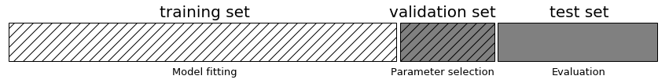

```python
mglearn.plots.plot_threefold_split()
```

- (설명)
- 훈련 세트로 모델을 만들고,
- 검증 세트로는 모델의 매개변수를 선택하고,
- 테스트 세트로는 선택된 매개변수의 성능을 평가

### 1-1-3 Grid Search 실습 두번째

```python
from sklearn.svm import SVC

# 학습(훈련+검증), 테스트로 분할
X_trainval, X_test, y_trainval, y_test = train_test_split(iris.data,
                                                    iris.target,
                                                    random_state=0)
```

```python
# 훈련+검증(X_trainvalid, y_trainvalid)을 활용하여
# 훈련, 검증로 분할
X_train, X_valid, y_train, y_valid = train_test_split(X_trainval,
                                                      y_trainval,
                                                      random_state=0)
```

```python
print("훈련 세트: {}, 검증 세트: {}, 테스트 세트: {}".format(X_train.shape[0],
                                               X_valid.shape[0],
                                               X_test.shape[0]  ))
```

```
훈련 세트: 84, 검증 세트: 28, 테스트 세트: 38
```

```python
best_score = 0

for gamma in [0.001, 0.01, 0.1, 1, 10, 100]:
    for C in [0.001, 0.01, 0.1, 1, 10, 100]:
        # 매개변수의 각 조합에 대해 SVC를 훈련
        svm = SVC(gamma=gamma, C=C)
        svm.fit(X_train, y_train)

        # 검증 세트로 SVC를 평가
        score = svm.score(X_valid, y_valid)

        # 점수가 더 높으면 매개변수와 함께 기록
        if score > best_score:
            best_score = score
            best_parameters = {'C':C, 'gamma':gamma}

# 훈련 세트와 검증 세트를 합쳐 모델을 다시 만든 후,
# 테스트 세트를 사용해 평가합니다.
svm = SVC(**best_parameters)
svm.fit(X_trainval, y_trainval)
test_score = svm.score(X_test, y_test)

print("검증 세트에서 최고 점수 : {:.2f}".format(best_score))
print("최적 매개변수 : ", best_parameters)
print("최적 매개변수에서 테스트 세트 점수 : {:.2f}".format(test_score))
```

```
검증 세트에서 최고 점수 : 1.00
최적 매개변수 :  {'C': 100, 'gamma': 0.001}
최적 매개변수에서 테스트 세트 점수 : 0.97
```

### 1-1-4 교차 검증을 사용한 그리드 서치

```python
import numpy as np
```

```python
for gamma in [0.001, 0.01, 0.1, 1, 10, 100]:
    for C in [0.001, 0.01, 0.1, 1, 10, 100]:
        # 매개변수의 각 조합에 대해 SVC를 훈련
        svm = SVC(gamma=gamma, C=C)

        # 교차 검증을 적용합니다.
        scores =  cross_val_score(svm, X_trainval, y_trainval, cv=5)

        # 교차 검증 정확도의 평균을 계산.
        score = np.mean(scores)

        # 점수가 더 높으면 매개변수와 함께 기록
        if score > best_score:
            best_score = score
            best_parameters = {'C':C, 'gamma':gamma}
```

```python
# 훈련 세트와 검증 세트를 합쳐 모델을 다시 만든 후,
# 테스트 세트를 사용해 평가합니다.
svm = SVC(**best_parameters)
svm.fit(X_trainval, y_trainval)
# test_score = svm.score(X_test, y_test)
```

```
SVC(C=100, gamma=0.001)
```

- 위의 코드와 같이 수행할 경우, 하나의 단점이라면 모델들(180개)을 학습 시키는데 걸리는 시간.

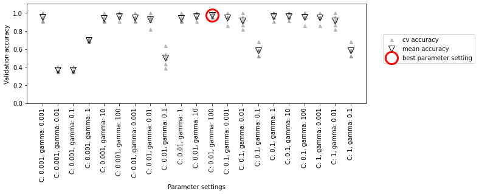

```python
mglearn.plots.plot_cross_val_selection()
```

### 1-1-5 교차 검증과 그리드 서치를 사용한 매개변수 선택과 모델 평가의 작업 흐름

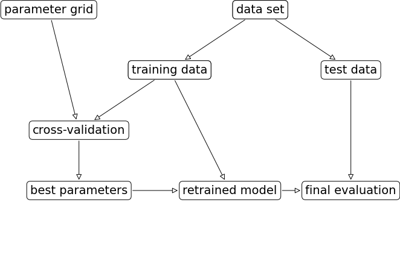

```python
mglearn.plots.plot_grid_search_overview()
```

### 1-1-6 GridSearchCV를 사용한 최적의 매개변수 찾기

- GridSearchCV를 제공.
- GridSearchCV를 사용하려면 먼저 딕셔너리 형태로 검색 대상 매개변수를 지정해야 한다.
- GridSearchCV는 모든 모델을 학습 시킨다.

```python
# 매개변수
param_grid = {'C':[0.001, 0.01, 0.1, 1, 10, 100],
              'gamma':[0.001, 0.01, 0.1, 1, 10, 100] }
print("매개변수 그리드 :\n", param_grid)
```

```
매개변수 그리드 :
 {'C': [0.001, 0.01, 0.1, 1, 10, 100], 'gamma': [0.001, 0.01, 0.1, 1, 10, 100]}
```

### GridSearchCV를 이용한 최적의 매개변수 찾기

```python
from sklearn.model_selection import GridSearchCV
from sklearn.svm import SVC
grid_search = GridSearchCV(SVC(), param_grid, cv=5, return_train_score=True)
grid_search
```

```
GridSearchCV(cv=5, estimator=SVC(),
             param_grid={'C': [0.001, 0.01, 0.1, 1, 10, 100],
                         'gamma': [0.001, 0.01, 0.1, 1, 10, 100]},
             return_train_score=True)
```

```python
# 데이터 셋 나누기
X_train, X_test, y_train, y_test = train_test_split(iris.data,
                                                    iris.target,
                                                    random_state=0)
```

```python
# 찾기 학습
grid_search.fit(X_train, y_train)
```

```
GridSearchCV(cv=5, estimator=SVC(),
             param_grid={'C': [0.001, 0.01, 0.1, 1, 10, 100],
                         'gamma': [0.001, 0.01, 0.1, 1, 10, 100]},
             return_train_score=True)
```

```python
# 훈련 후, 테스트로 적용 후, 점수
grid_search.score(X_test, y_test)
```

```
0.9736842105263158
```

### 포인트 : 매개변수를 선택하는데 테스트 세트를 사용하지 않음.

### 선택한 매개변수 및 교차 검증의 정확도 확인

- 위에서의 테스트 세트로 적용한 점수와 아래의 코드의 best*score*(훈련세트)는 다른 점수이다.
- 선택한 매개변수는 best*params* 속성에 담겨져 있다.

```python
print("최적 매개변수 :", grid_search.best_params_)
print("최고 교차 검증 점수 : {:.2f}".format(grid_search.best_score_))
```

```
최적 매개변수 : {'C': 10, 'gamma': 0.1}
최고 교차 검증 점수 : 0.97
```

```python
### 최고 성능 모델 확인
print("최고 성능 모델 :\n", grid_search.best_estimator_)
```

```
최고 성능 모델 :
 SVC(C=10, gamma=0.1)
```

### 1-1-7 교차 검증 결과 분석

- 그리드 서치는 연산 비용이 매우 크다. 비교적 간격을 넓게 하여 적은 수의 그리드로 시작하는 것이 좋다.
- 교차 검증된 그리드 서치의 결과를 분석하여 검색 확장이 가능하다.
- 그리드 서치의 결과는 검색과 관련한 여러 정보가 함께 저장되어 있는 딕셔너리인 cv_results_속성에 담겨 있다.

```python
import pandas as pd
pd.set_option('display.max_columns', None)

# DataFrame으로 변환
results = pd.DataFrame(grid_search.cv_results_)
results.shape
```

```
(36, 22)
```

```python
# 처음 다섯 개 행을 출력
display(np.transpose(results.head() ))
```

|  | 0 | 1 | 2 | 3 | 4 |
| --- | --- | --- | --- | --- | --- |
| mean_fit_time | 0.00400019 | 0.00620108 | 0.0049994 | 0.0278009 | 0.00379982 |
| std_fit_time | 0.00109524 | 0.0030575 | 0.00253315 | 0.0278525 | 0.00074754 |
| mean_score_time | 0.00199976 | 0.0187994 | 0.00420389 | 0.00439973 | 0.00440049 |
| std_score_time | 0.00109493 | 0.026569 | 0.0024864 | 0.0025755 | 0.0038269 |
| param_C | 0.001 | 0.001 | 0.001 | 0.001 | 0.001 |
| param_gamma | 0.001 | 0.01 | 0.1 | 1 | 10 |
| params | {'C': 0.001, 'gamma': 0.001} | {'C': 0.001, 'gamma': 0.01} | {'C': 0.001, 'gamma': 0.1} | {'C': 0.001, 'gamma': 1} | {'C': 0.001, 'gamma': 10} |
| split0_test_score | 0.347826 | 0.347826 | 0.347826 | 0.347826 | 0.347826 |
| split1_test_score | 0.347826 | 0.347826 | 0.347826 | 0.347826 | 0.347826 |
| split2_test_score | 0.363636 | 0.363636 | 0.363636 | 0.363636 | 0.363636 |
| split3_test_score | 0.363636 | 0.363636 | 0.363636 | 0.363636 | 0.363636 |
| split4_test_score | 0.409091 | 0.409091 | 0.409091 | 0.409091 | 0.409091 |
| mean_test_score | 0.366403 | 0.366403 | 0.366403 | 0.366403 | 0.366403 |
| std_test_score | 0.0224845 | 0.0224845 | 0.0224845 | 0.0224845 | 0.0224845 |
| rank_test_score | 22 | 22 | 22 | 22 | 22 |
| split0_train_score | 0.370787 | 0.370787 | 0.370787 | 0.370787 | 0.370787 |
| split1_train_score | 0.370787 | 0.370787 | 0.370787 | 0.370787 | 0.370787 |
| split2_train_score | 0.366667 | 0.366667 | 0.366667 | 0.366667 | 0.366667 |
| split3_train_score | 0.366667 | 0.366667 | 0.366667 | 0.366667 | 0.366667 |
| split4_train_score | 0.355556 | 0.355556 | 0.355556 | 0.355556 | 0.355556 |
| mean_train_score | 0.366092 | 0.366092 | 0.366092 | 0.366092 | 0.366092 |
| std_train_score | 0.00558129 | 0.00558129 | 0.00558129 | 0.00558129 | 0.00558129 |

- 각 열은 하나의 매개변수를 가진다.
- 각 설정에 대한 교차 검증의 모든 분할의 평균값, 표준편차를 포함한 결과가 기록되어 있다.
- 매개변수 그리드가 2차원이므로 C와 gamma는 히트맵으로 시각화하기가 좋다.
- 테스트 점수의 표준편차가 작은 매개변수 조합이 더 좋다고 판단할 수 있다.

### 기타 방법

- GridSearchCV이외에 RandomizedSearchCV가 있다.
  - 이방법은 GridSearchCV보다 크게 뒤지지 않고 검색이 빠르다.
  - 매개변수의 조합이 매우 많거나 규제 매개변수와 같이 연속형 값을 조정해야 할 때 널리 사용.
  - RandomizedSearchCV의 매개변수 샘플링 기본 횟수는 10개이며 n_iter 옵션에서 조절 가능

### 히트맵

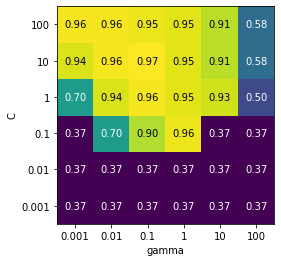

```python
scores = np.array(results.mean_test_score).reshape(6,6)

# 교차 검증 평균 점수 히트맵 그래프
mglearn.tools.heatmap(scores,
                      xlabel='gamma', xticklabels=param_grid['gamma'],
                      ylabel='C', yticklabels=param_grid['C'],
                      cmap='viridis'
                      )
```

### 히트맵의 이해

- SVC는 매개변수 설정에 민감.
- 많은 매개변수는 40%부근의 낮은 정확도를 보인다.
- 어떤 설정에서는 96%이상의 만들었다.
- 높은 성능을 얻으려면 매개 변수 조정이 매우 중요하다.
- 어떻게 조정하는가에 따라 정확도가 40%에서 96%까지 차이가 난다.

### 1-1-8 매개변수의 검색 범위가 적절하지 않는다면

```python
import matplotlib.pyplot as plt
```

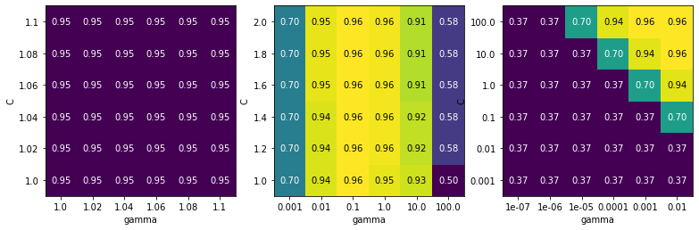

```python
fig, axes = plt.subplots(1,3, figsize=(13,5))

param_grid_linear = {'C':np.linspace(1.0, 1.1, 6),
                     'gamma': np.linspace(1.0, 1.1, 6) }

param_grid_one_log = {'C':np.linspace(1,2,6),
                     'gamma': np.logspace(-3,2,6) }

param_grid_range = {'C': np.logspace(-3,2,6),
                    'gamma': np.logspace(-7,-2,6) }

for param_grid, ax in zip([param_grid_linear,
                            param_grid_one_log,
                            param_grid_range], axes):
    grid_search = GridSearchCV(SVC(), param_grid, cv=5)
    grid_search.fit(X_train, y_train)
    scores = grid_search.cv_results_['mean_test_score'].reshape(6,6)


    # 교차 검증 평균 점수 히트맵 그래프
    scores_image = mglearn.tools.heatmap(scores,
                      xlabel='gamma', xticklabels=param_grid['gamma'],
                      ylabel='C', yticklabels=param_grid['C'],
                      cmap='viridis', ax=ax
                      )
```

- 첫번째 그래프는 점수 변화가 없어 전체 매개변수 그리드가 같은 색이다.
- 두번째 그래프는 세로 때 형태. 이는 gamma매개변수만 정확도에 영향을 준다.
  - 즉 gamma 매개변수는 적절한 범위를 탐색하고 있지만, C매개변수는 그렇지 못하든지, 아니면 중요한 매개변수가 아닐 수도 있습니다.
- 세번째 그래프는 C와 gamma 둘 모두에 따라 값이 변했다. 하지만 그래프 왼쪽 아래 영역에서는 아무런 변화가 없다.

### 처음에는 매우 극단적인 값을 적용 후, 매개변수를 바꿔가며 정확도가 변하는지 살펴보기

- history
  - 2020/10/01